# Spatial analysis report on Lambeth

2025-01-06

## Findings

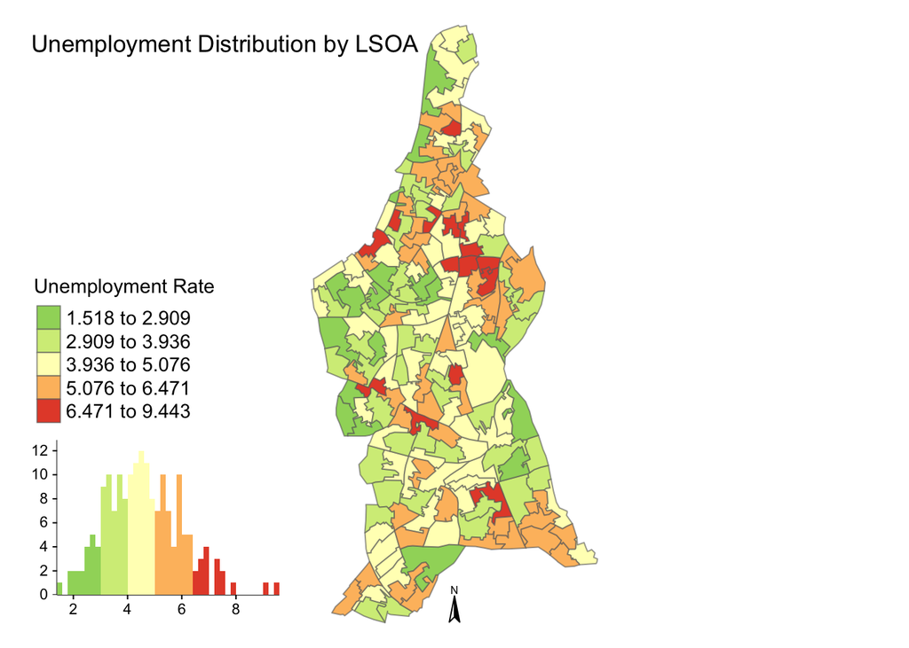

Figure 1: Unemployment Distribution Map by LSOA

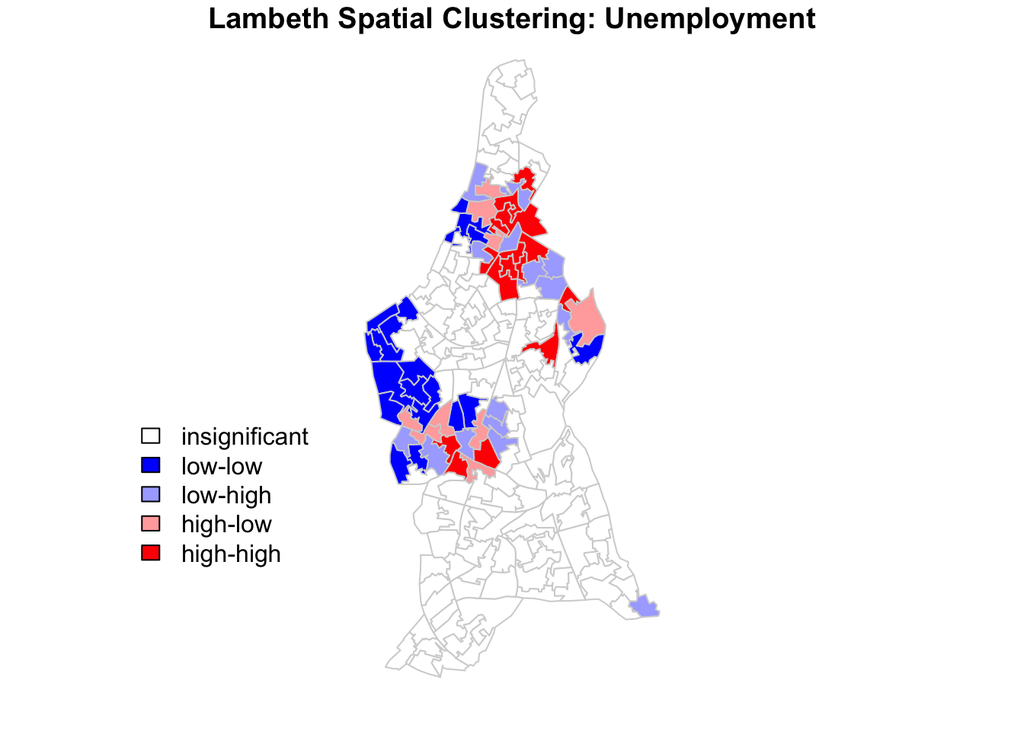

Figure 2: LISA Cluster Map of Spatial Autocorrelation

High-High cluster, indicated by dark red, represents areas with high unemployment that are geographically concentrated and adjacent. In the map, north-east Lambeth displays prevalent high-high clusters, while some areas in mid-Lambeth show the same characteristics, corresponding to the previous unemployment distribution map. Conversely, low-low clusters are highlighted in dark blue, representing closely located low unemployment areas. On the map, western Lambeth exhibits significant low-low areas.

Low-high and high-low clusters represent areas with both low and high unemployment rate that are more difficult to explain. The map shows notable low-high and high-low clusters in north-west and north-east Lambeth, indicated in light blue and light red, signifying a lower unemployed region bounded by higher unemployed areas and vice versa. The rest of the map is dominated by insignificant clustering, indicating a more randomly dispersed unemployment distribution.

Therefore, Lambeth Council should target specific policies to tackle those high-unemployment clusters, including per-unit business subsidies or improved transportation, to ensure the area is worth investing in and creating further job opportunities. However, Munyoro (2017) argues that unemployment benefits may lead businesses to be less willing to invest in assisted areas, as there may be fewer skilled workers due to being deskilled or being unemployed for long periods. Thus, he recommends reducing unemployment benefits in order to encourage the unemployed to take low paid jobs. For low-high and high-low regions, further research should be focused on the characteristics that cause such divergent employment rates in closely related areas.

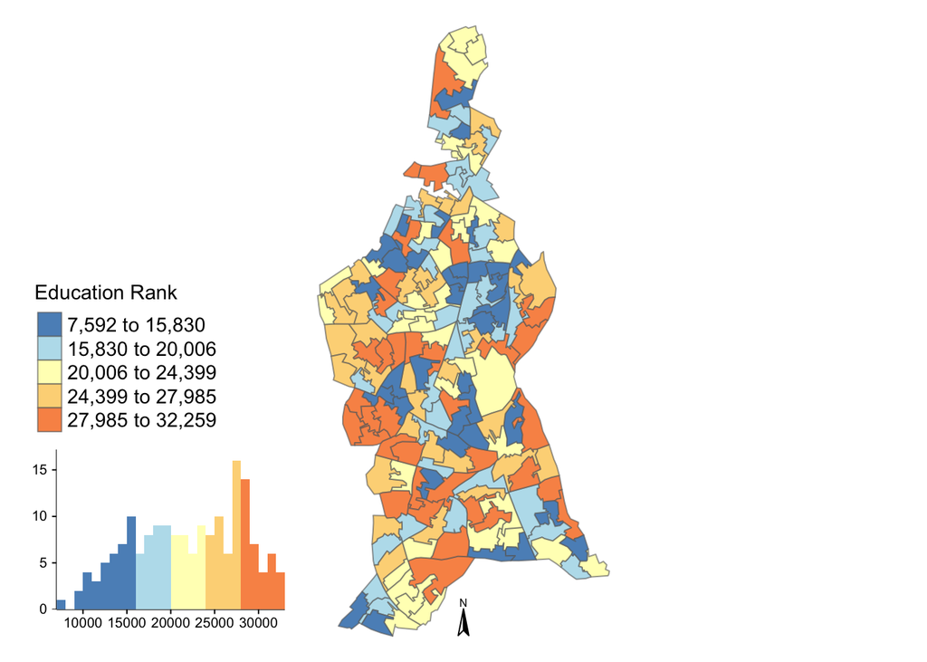

Figure 3: Education distribution and GWR coefficient of education

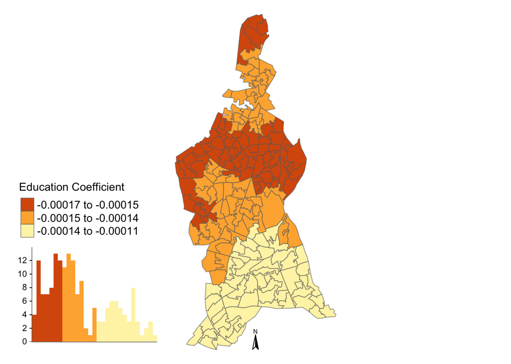

Figure 3: Education distribution and GWR coefficient of education

This report has demonstrated that in London, particularly Lambeth, high levels of educational deprivation are coupled with high levels of unemployment rates. These findings align with other studies elsewhere, for example, graduates in Paris are more likely to be employed than individuals with educational deprivation (OECD, 2000). The findings relating to Lambeth can be partially explained by the signaling theory that employers see education qualification as an indicator of the accumulation of capital and productivity, and people with lower educational attainment are deemed as unqualified and rejected in job interviews.

In conclusion, northeast Lambeth is determined as highly unemployed and is geographically close to other regions with high unemployment rates. In addition, north-east Lambeth is found to have low education levels, with a strong correlation with its high unemployment rates. Thus, Lambeth Council should focus on this area, invest in its education infrastructure, and create work opportunities, including providing subsidies for local businesses to increase occupations and increase access to devices to enhance individual study efficiency and ensure higher education quality. Further research should investigate the characteristics and causes of eastern Lambeth, where a low-unemployment region is mixed with a high-unemployment region.

## Technical Appendix

Classification: Quantile and Jenks

In this study, both Quantile and Jenks methods are used to classify different variables. For education ranks with continuous values, quantile classification is adopted to group the values into five equal groups, ensuring the comparison among each group is meaningful without concerning data skewness. For Moran statistics, local R2, and Education coefficient maps, Jenks method is used to highlight the breaks with different groups. Therefore, variance within classes is minimized and variance between classes is maximized (Jenks,1967).

Clustering: Moran’s Test

Moran’s I autocorrelation is used to identify clustering patterns in Lambeth. Unlike traditional point-pattern analysis, which requires specific household coordinates, Moran’s I is better suited for this analysis as it relies on the output areas provided in the data.

The study used Rook’s case and Queen’s case definition of Neighbors at the beginning. After comparing the average links and plotting Moran’s I local statistics map, results are found to be unrealistic in that some value exceeds +1 or -1. Therefore, both Rook’s case and Queen’s case are not applicable, and distance-based neighbourhood definition is adopted. By comparing Moran’s global statistics and p-value, the optimal distance threshold is set as 2000m.

By setting the distance threshold as 2000m and the confidence level at 0.95, the Moran’s I global statistics return a Z-score of 2.8574 and a p-value of 0.0021, rejecting the null hypothesis that Lambeth is randomly clustered. Moran I statistics of 0.032 signifies a positive spatial autocorrelation, though the strength is relatively weak. A Local Indicators of Spatial Association map (LISA) is adopted to inform Lambeth Council that highlighted regions with clustering, warranting targeted policies and further investigation.

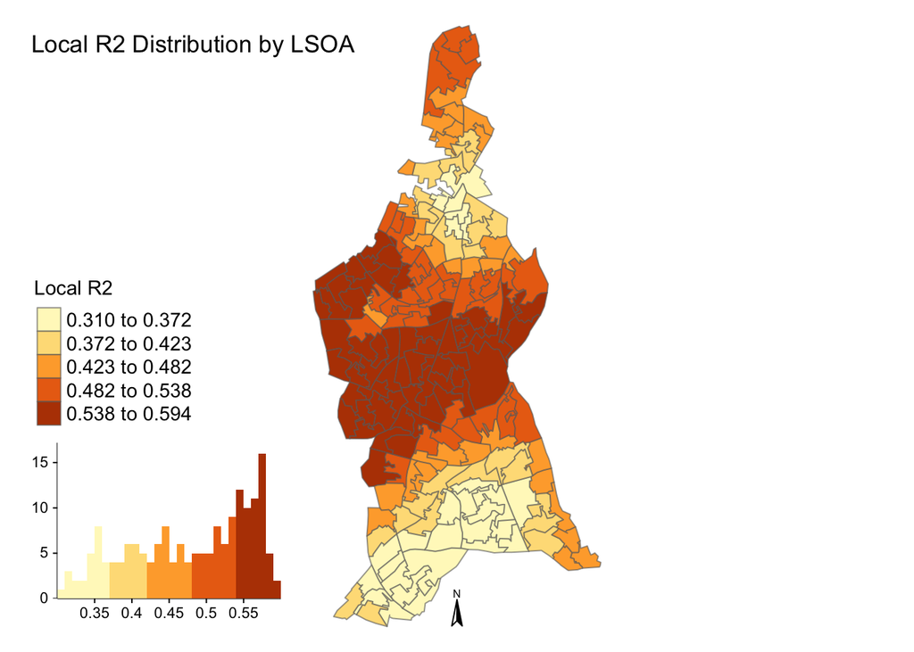

figure 4: Local R2 distribution

Limitation: Since unemployment data is formatted as OA units, converting to LSOA units requires manipulation of data, and this study simply computes the mean of various OAs into one LSOA unemployment value. Though it is reliable to convert from smaller to larger units, demonstrated by Norman (2012), it may incur biases as the mean can be greatly influenced by outliers in an LSOA unit. In addition, to explore unemployment’s relationship with educational attainments, the IMD2019 dataset is selected with census 2021. In recent years, the job environment has been detrimentally affected by COVID-19 (Tetlow, 2020), and the coefficient of educational attainment can be over-magnified. Education rank distribution adopts quantile classification, but as the Lambeth data is extracted from UK data, education rank is not in Lambeth order and may confuse interpretation. Future research is recommended to search for updated 2021 IMD LSOAs data and subset Lambeth data and causes of low-high and high-low regions should be further investigated to target relevant policies.

To conclude, every method is carefully selected to meet the requirements and address unique characteristics at spatial analysis.

## Reference list

Barry, F. and Hannan, A., 2019. Education, deprivation, hysteresis, unemployment. Unemployment in Ireland, pp.75-86.

Jenks, G.F., 1967. The data model concept in statistical mapping. International yearbook of cartography, 7, pp.186-190.

MUNYORO, G., 2017. THE SIGNIFICANCE OF REGIONAL POLICY TO SCOTTISH ECONOMY.

Lu, B., Hu, Y., Yang, D., Liu, Y., Liao, L., Yin, Z., Xia, T., Dong, Z., Harris, P., Brunsdon, C. and Comber, L., 2023. GWmodelS: A software for geographically weighted models. SoftwareX, 21, p.101291.

Norman, P. and Riva, M., 2012. Population health across space and time: the geographical harmonisation of the Office for National Statistics Longitudinal Study for England and Wales. Population, Space and Place, 18(5), pp.483-502.

Organisation for Economic Co-operation and Development. (2000). From initial education to working life: Making transitions work. Paris: OECD.

Tetlow, G., Pope, T. and Dalton, G., 2020. Coronavirus and unemployment. Institute for Government Insight.

## Appendix

```r
setwd("~/Desktop/Code/R studio")

# Load required libraries
library(sf)
library(spatstat)
library(tmap)
library(dplyr)
library(spgwr)
library(spdep)
library(grid)
library(gridExtra)

# Read input data
census_data <- read.csv("~/Downloads/Worksheet_Data/eng_wales_practical_data.csv")
lsoa_shapefile <- st_read(dsn = "~/Downloads/worksheet_data/Census_OA_Shapefile.geojson")
oa_shapefile <- st_read("~/Downloads/Worksheet_Data/OA_2021_EW_BGC_V2.shp")

# Process centroids for LSOA
lsoa_centroids <- st_centroid(lsoa_shapefile)
lsoa_lambeth <- oa_shapefile[grepl('Lambeth', oa_shapefile$LSOA21NM),]

# Merge census data with the LSOA shapefile based on OA code
lambeth_census <- merge(lsoa_lambeth, census_data, by.x = "OA21CD", by.y = "OA")
lambeth_census_lsoa <- lambeth_census[, -1] # Remove redundant column
st_write(lambeth_census, dsn = "~/Downloads/Worksheet_Data/Lambeth_Census_Shapefile.geojson", driver="GeoJSON")

# Create OA to LSOA mapping
oa_to_lsoa <- lsoa_lambeth[, c("OA21CD", "LSOA21CD")]

# Merge census data with LSOA mapping based on OA code
merged_data <- merge(census_data, oa_to_lsoa, by.x = "OA", by.y = "OA21CD")

# Aggregate data by LSOA (e.g., calculate average unemployment rate)
aggregated_data <- merged_data %>%
  group_by(LSOA21CD) %>%
  summarise(Unemployment_Rate = mean(Unemployed, na.rm = TRUE))

# Merge aggregated data with LSOA shapefile
lsoa_areas <- st_read("~/Downloads/Worksheet_Data/Lower_layer_Super_Output_Areas_2021_EW_BGC_V3.geojson")
lsoa_merged <- merge(lsoa_areas, aggregated_data, by.x = "LSOA21CD", by.y = "LSOA21CD")



tm_shape(lsoa_merged) +
  tm_fill("Unemployment_Rate", legend.hist = TRUE, palette = "-RdYlGn" , style = "jenks", n = 5, title = "Unemployment Rate") +
  tm_borders(alpha = .6) +
  tm_compass(size = 2, fontsize = 0.5,position = c("center","bottom"))+
  tm_layout(title = "Unemployment Distribution by LSOA",legend.text.size = 0.9,frame = FALSE,asp = 0,legend.position = c("left","bottom"),legend.hist.width = 0.3,title.size = 1.1)

# Spatial neighbors for poly2nb and different types of adjacency
neighbours <- poly2nb(lsoa_merged)
neighbours_rook <- poly2nb(lsoa_merged, queen = FALSE)

# Plot both types of neighbor relationships
par(mfrow = c(1, 2))
plot(neighbours, st_geometry(lsoa_merged), col = 'red')
plot(neighbours_rook, st_geometry(lsoa_merged), col = 'blue')

# Create spatial weight list for Moran's test
listw <- nb2listw(neighbours_rook, style = "W")

# Run Moran's I test for spatial autocorrelation
moran.test(lsoa_merged$Unemployment_Rate, listw)

# Calculate lagged unemployment rate and plot
lagged_rate <- lag.listw(listw, lsoa_merged$Unemployment_Rate)
unemployment_rate <- lsoa_merged$Unemployment_Rate
plot(unemployment_rate, lagged_rate)
abline(h = mean(unemployment_rate), lty = 2)
abline(v = mean(lagged_rate), lty = 2)

# Recenter the data
recentered_uep <- unemployment_rate - mean(unemployment_rate)
recentered_lag <- lagged_rate - mean(lagged_rate)
plot(recentered_uep, recentered_lag)
abline(h = 0, lty = 2)
abline(v = 0, lty = 2)

# Linear model for spatial lag
lm_model <- lm(recentered_lag ~ recentered_uep)
abline(lm_model, lty = 3)

# Local Moran's I
local_moran <- localmoran(x = lsoa_merged$Unemployment_Rate, listw = nb2listw(neighbours_rook, style = "W"))
moran_map <- cbind(lsoa_merged, local_moran)

# Plot Local Moran's I map
tm_shape(moran_map) +
  tm_fill(col = "Ii", style = "jenks", title = "Local Moran's I statistics")

# Nearest neighbors based on distance (2 km)
distance_neighbours <- dnearneigh(st_centroid(lsoa_merged), 0, 2000)
moran.test(lsoa_merged$Unemployment_Rate, listw = nb2listw(distance_neighbours, style = "W"))

# Local Moran's I with distance-based neighbors
local_moran_distance <- localmoran(x = lsoa_merged$Unemployment_Rate, listw = nb2listw(distance_neighbours, style = "W"))
moran_map_distance <- cbind(lsoa_merged, local_moran_distance)

# Plot Local Moran's I with distance-based neighbors
tm_shape(moran_map_distance) +
  tm_fill(col = "Ii", style = "jenks", title = "Local Moran's I statistic (Distance-Based)")

# Define quadrants based on recentered data
quadrant <- numeric(length = nrow(local_moran_distance))
significance_threshold <- 0.05
quadrant[recentered_uep < 0 & recentered_lag < 0] <- 1
quadrant[recentered_uep < 0 & recentered_lag > 0] <- 2
quadrant[recentered_uep > 0 & recentered_lag < 0] <- 3
quadrant[recentered_uep > 0 & recentered_lag > 0] <- 4
quadrant[local_moran_distance[, 5] > significance_threshold] <- 0

# Define color scheme for quadrant visualization
color_breaks <- c(0, 1, 2, 3, 4)
colors <- c("white", "blue", rgb(0, 0, 1, alpha = 0.4), rgb(1, 0, 0, alpha = 0.4), "red")

# Plot the spatial clustering map
plot(lsoa_merged[1], border = "lightgrey",
     col = colors[findInterval(quadrant, color_breaks, all.inside = FALSE)],
     main = "Lambeth Spatial Clustering: Unemployment")
legend("bottomleft", legend = c("insignificant", "low-low", "low-high", "high-low", "high-high"), fill = colors, bty = "n")

# Read IMD data and merge with census data
imd_data <- st_read(dsn = "~/Downloads/English IMD 2019/IMD_2019.dbf")
imd_lambeth <- imd_data[grepl('Lambeth', imd_data$lsoa11nm),]
merged_imd_census <- merge(imd_lambeth, aggregated_data, by.x = "lsoa11cd", by.y = "LSOA21CD")

# Fit linear model for unemployment rate and education rank
lm_model_imd <- lm(merged_imd_census$Unemployment_Rate ~ merged_imd_census$EduRank)
summary(lm_model_imd)

# Plot model diagnostics
plot(lm_model_imd, which = 3)

# Residuals and mapping
residuals_data <- residuals(lm_model_imd)
map_residuals <- cbind(merged_imd_census, residuals_data)
qtm(map_residuals, fill = "residuals_data")

# GWR model
imd_census_spatial <- as(merged_imd_census, "Spatial")
gwr_bandwidth <- gwr.sel(imd_census_spatial$Unemployment_Rate ~ imd_census_spatial$EduRank, data = imd_census_spatial, adapt = TRUE)
gwr_model <- gwr(imd_census_spatial$Unemployment_Rate ~ imd_census_spatial$EduRank, data = imd_census_spatial, adapt = gwr_bandwidth, hatmatrix = TRUE, se.fit = TRUE)

# GWR results
gwr_results <- as.data.frame(gwr_model$SDF)
gwr_map <- cbind(imd_census_spatial, as.matrix(gwr_results))

# Plot GWR Local R2 distribution map
tm_shape(gwr_map) +
  tm_fill("localR2", style = "jenks", legend.hist = TRUE, n = 5, title = "Local R2") +
  tm_borders(alpha = 0.6) +
  tm_compass(size = 2, fontsize = 0.5,position = c("center","bottom"))+
  tm_layout(title = "Local R2 Distribution by LSOA", legend.text.size = 0.9,frame = FALSE,asp = 0,legend.position = c("left","bottom"),legend.hist.width = 0.3,title.size = 1.1)

# Plot education rank and coefficient maps
map1 <- tm_shape(gwr_map) +
  tm_fill("EduRank", n = 5, style = "quantile", title = "Education Rank", palette = "-RdYlBu", legend.hist = TRUE) +
  tm_borders(alpha = 0.6) +
  tm_compass(size = 2, fontsize = 0.5,position = c("center","bottom"))+
  tm_layout(legend.text.size = 0.9,frame = FALSE,asp = 0,legend.position = c("left","bottom"),legend.hist.width = 0.3,title.size = 1.1)

map2 <- tm_shape(gwr_map) +
  tm_fill("imd_census_spatial.EduRank", n = 3, style = "jenks", title = "Education Coefficient", legend.hist = TRUE) +
  tm_layout(legend.text.size = 0.9,frame = FALSE,asp = 0,legend.position = c("left","bottom"),legend.hist.width = 0.3,title.size = 1.1) +
  tm_compass(size = 2, fontsize = 0.5,position = c("center","bottom"))+
  tm_borders(alpha = 0.6)

# Display both maps
print(map1)
print(map2)

# Correlation and scatter plot for GWR results
round(cor(gwr_results[, c(3, 5, 7, 8)], use = "complete.obs"), 2)
pairs(gwr_results[, c(3, 5, 7, 8)], pch = ".")

library(psych)
describe(lsoa_merged$Unemployment_Rate)
describe(merged_imd_census$EduRank)
```

## Dataset description

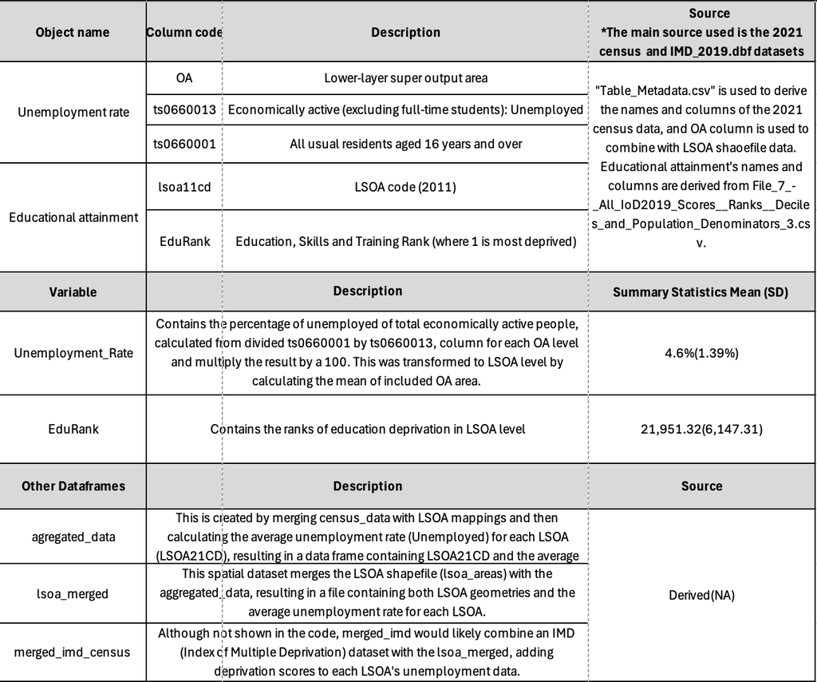

table